# STAT 578 - Fall 2019 - Assignment 2

Frederick (Eric) Ellwanger - fre2

September 28, 2019

## Excersise 1

#### 1. Consider the two different hyperprior formulations for the binomial hierarchical model of Lesson 3.2: Hierarchical Modeling Fundamentals. This exercise shows how different those priors are.

#### **(1)(a)** The first prior formulation was:

$$\begin{align*}
\theta_j | \alpha, \beta \sim Beta(\alpha, \beta) \\
\alpha, \beta \sim iid \hspace{2 mm} Expon(0.001)
\end{align*}$$

#### **(1)(a)(i)** Independently simulate 1000 pairs ($\alpha, \beta$) from their hyperprior, and produce a scatterplot of log($\beta$) versus log($\alpha$).

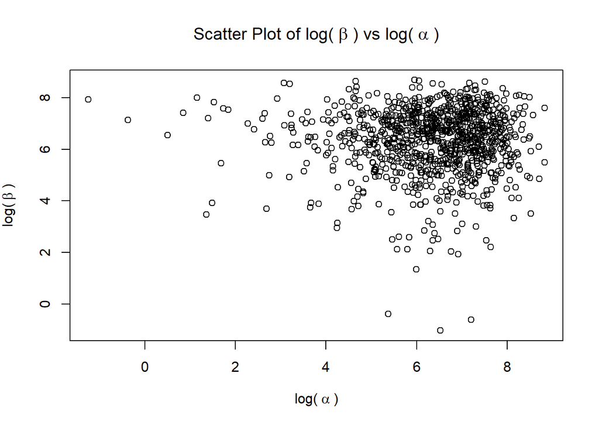

```r
set.seed(19690223)

#Simulate 1000 draws of alpha and beta
alpha = rexp(1000, rate = 0.001)
beta = rexp(1000, rate = 0.001)

plot(log(alpha), log(beta), ylab = bquote("log("~beta~")"), xlab = bquote("log("~alpha~")"),
                            main = bquote("Scatter Plot of log("~beta~") vs log("~alpha~")"))
```

#### **(1)(a)(ii) Using the simulated pairs ($\alpha$, $\beta$), forward-simulate $\theta_j$ , and produce a histogram of the result (an approximation of its marginal prior).**

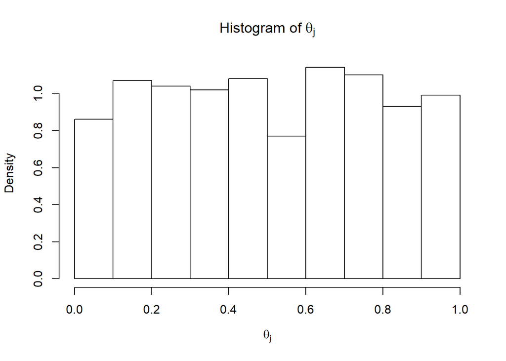

```r
thetaj = rbeta(1000, alpha, beta)
hist(thetaj, freq = FALSE, xlab = bquote(theta[j]), main = bquote("Histogram of"~theta[j]))
```

#### **(1)(b) The second prior formulation was**

$$\begin{equation}
\begin{aligned}
\theta_j | \alpha, \beta \sim Beta(\alpha, \beta) \\
\alpha = \frac{\phi_1}{\phi_2^2} \hspace{8 mm} \beta = \frac{(1 - \phi_1)}{\phi_2^2} \\
\phi_1 \sim U(0, 1) \hspace{12mm} \phi_2 \sim U(0, 1000)
\end{aligned}
\end{equation}$$

#### **(1)(b)(i) Independently simulate 1000 pairs ($\alpha$, $\beta$) from their hyperprior, and produce a scatterplot of log($\beta$) versus log($\alpha$).**

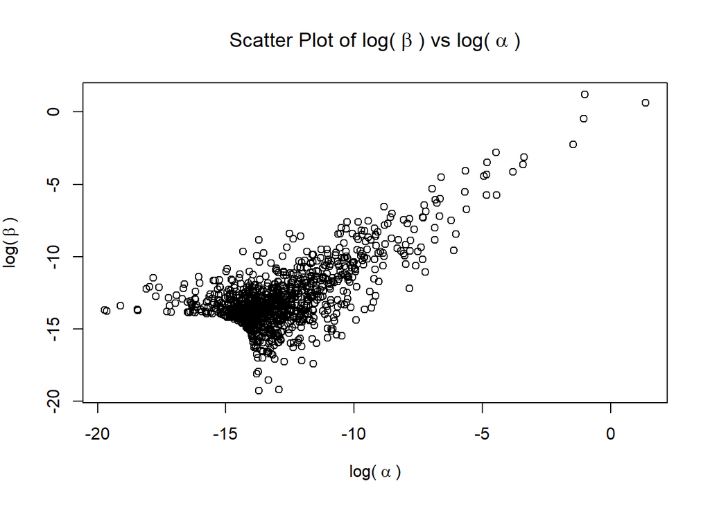

```r
set.seed(19690223)

#Simulate 1000 draws of phi1 and phi2
phi1 = runif(1000, 0, 1)
phi2 = runif(1000, 0, 1000)

alpha = phi1/phi2^2
beta = (1 - phi1)/phi2^2

plot(log(alpha), log(beta), ylab = bquote("log("~beta~")"), xlab = bquote("log("~alpha~")"),
                            main = bquote("Scatter Plot of log("~beta~") vs log("~alpha~")"))
```

#### **(1)(b)(ii) Using the simulated pairs ($\alpha$, $\beta$), forward-simulate $\theta_j$ , and produce a histogram of the result (an approximation of its marginal prior).**

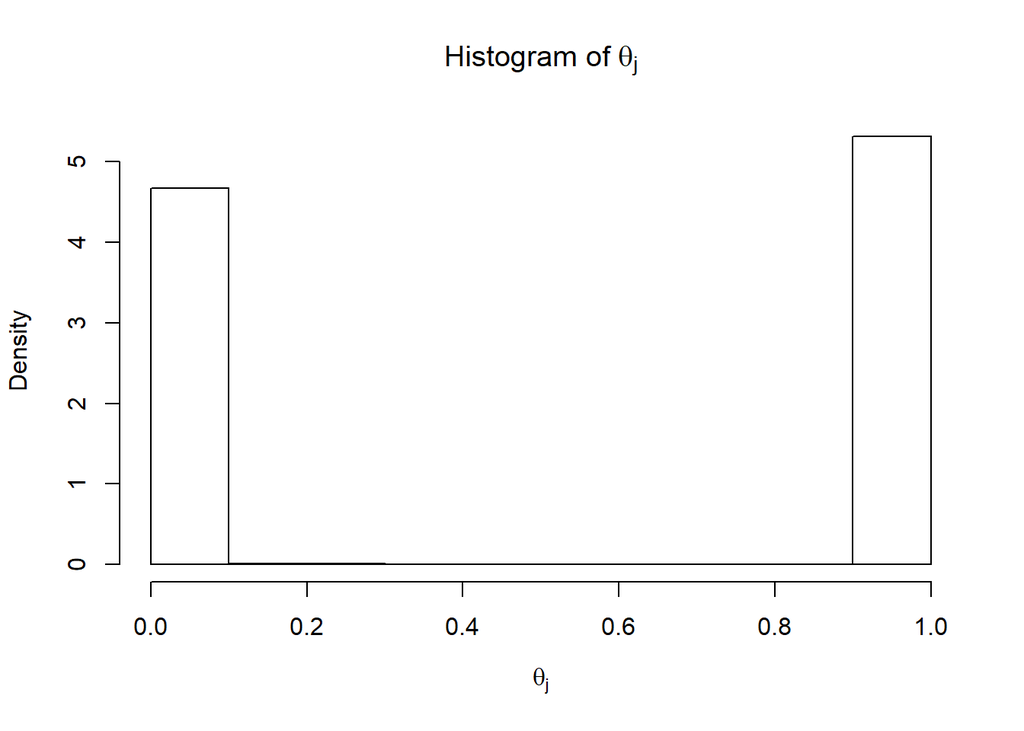

```r
thetaj = rbeta(1000, alpha, beta)
hist(thetaj, freq = FALSE, xlab = bquote(theta[j]), main = bquote("Histogram of"~theta[j]))
```

## Excersise 2

#### **(2) Consider this Bayesian hierarchical model:**

$$\begin{equation}
\begin{aligned}
\hat{\psi_j} | \psi_j \sim indep. \mathcal{N}(\psi_j,\sigma_j^{2}) \hspace{8mm} j = 1, ..., 12 \\
\psi_j | \psi_0, \sigma_0 \sim iid \hspace{4mm} \mathcal{N}(\psi_0,\sigma_0^{2}) \hspace{8mm} j = 1, ..., 12 \\
\psi_0 \sim\ \mathcal{N}(0,1000^{2}) \\
\sigma_0 \sim U(0, 1000)
\end{aligned}
\end{equation}$$

#### **(2)(a) Specify improper densities that the proper hyperpriors given above appear to be approximating. (Which parameters are the hyperparameters?)**

**The hyperparameters are: $\psi_0$ and $\sigma_0$**
**The improper densities of the hyperpriors appear to be approximating:**
$$\begin{equation}
\begin{aligned}
p(\psi_0) \propto 1 \hspace{8mm} (flat \hspace{2mm} on \hspace{2mm} -\infty < \hspace{2mm} \psi_0 \hspace{2mm} < \infty) \\
p(\sigma_0) \propto 1 \hspace{8mm} (flat \hspace{2mm} on \hspace{2mm} 0 < \hspace{2mm} \sigma_0 \hspace{2mm} < \infty)
\end{aligned}
\end{equation}$$

#### **(2)(b) Draw a directed acyclic graph (DAG) appropriate for this model. (Use the notation introduced in lecture, including plates.) You may draw it neatly by hand or use software.**

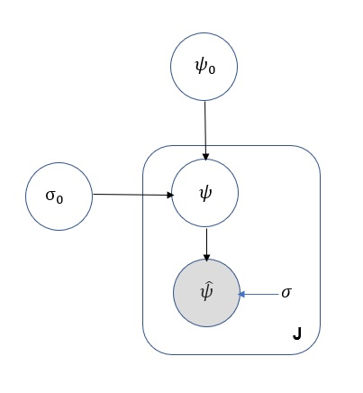

#### **(2)(c) Using the template asgn2template.bug provided on the course website, form a JAGS model statement (corresponding to your graph). Also, set up any R (rjags) statements appropriate for creating a JAGS model. [Remember: JAGS dnorm uses precisions, not variances!]**

```
model {
  for (j in 1:length(psi_hat)) {
    psi_hat[j] ~ dnorm(psi[j], 1/sigma[j]^2)
    psi[j] ~ dnorm(psi0, 1/sigmasq0)
  }

  psi0 ~ dnorm(0, 1/1000^2)
  sigma0 ~ dunif(0, 1000)

  sigmasq0 <- sigma0^2
}
```

```r
library(rjags)
d = read.table("asgn2data.txt", header=TRUE)
m1 = jags.model("asgn2template.bug", d)
```

#### **(2)(d) Run at least 10,000 iterations of burn-in, then 100,000 iterations to use for inference. For both $\psi_0$ and $\sigma_0^2$ (not $\sigma_0$), produce a posterior numerical summary and also graphical estimates of the posterior densities. Explicitly give the approximations of the posterior expected values, posterior standard deviations, and 95% central posterior intervals. (Just showing R output is not enough!)**

```r
update(m1, 10000)   #Burn-in

x1 = coda.samples(m1, c("psi0", "sigmasq0"), n.iter = 100000)
summary(x1)
```

```
##
## Iterations = 11001:111000
## Thinning interval = 1
## Number of chains = 1
## Sample size per chain = 100000
##
## 1. Empirical mean and standard deviation for each variable,
##    plus standard error of the mean:
##
##           Mean    SD Naive SE Time-series SE
## psi0     0.214 0.133 0.000419       0.000648
## sigmasq0 0.150 0.132 0.000418       0.000984
##
## 2. Quantiles for each variable:
##
##             2.5%    25%   50%   75% 97.5%
## psi0     -0.0309 0.1282 0.207 0.293 0.497
## sigmasq0  0.0185 0.0674 0.115 0.189 0.495
```

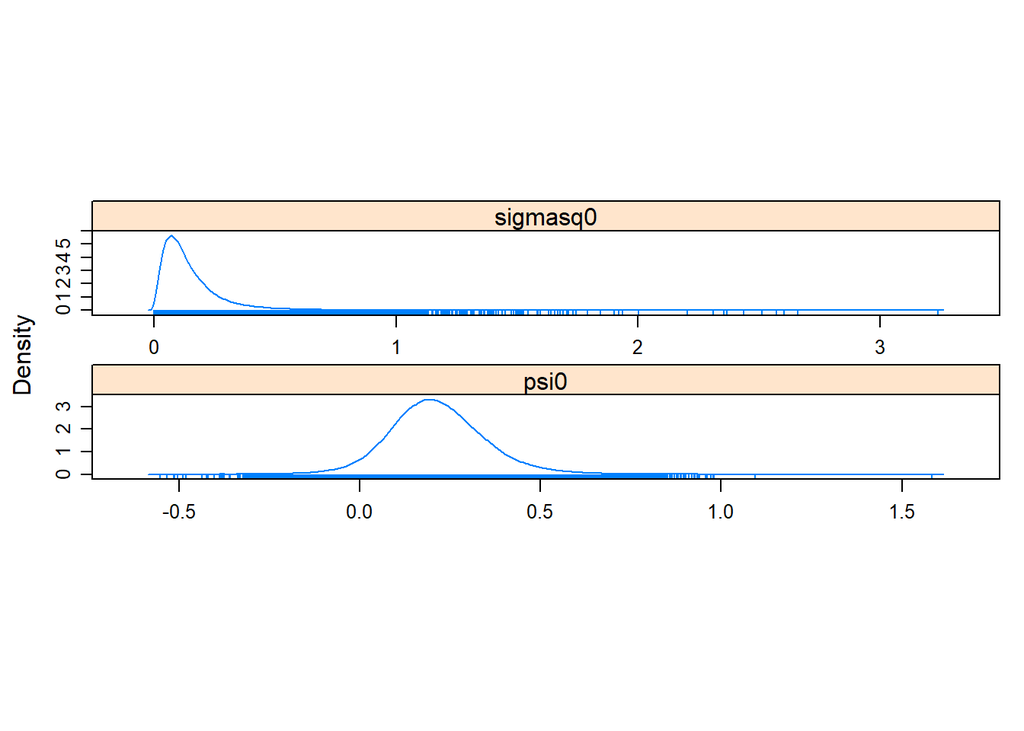

```r
require(lattice)
densityplot(x1[,c("psi0", "sigmasq0")])
```

**posterior expected value of $\psi_0 \approx$ 0.214**  
**posterior expected value of $\sigma_0^2 \approx$ 0.15**

**posterior standard deviation of $\psi_0 \approx$ 0.133**  
**posterior standard deviation of $\sigma_0^2 \approx$ 0.132**

**95% central posterior interval for $\psi_0 \approx$ (-0.031, 0.497)**  
**95% central posterior interval for $\sigma_0^2 \approx$ (0.018, 0.495)**

#### **(2)(e) Suppose a new case-control study is to be performed, and assume that its log-odds standard error (new $\sigma$) will be 0.25. Assume the $\psi$ for the new study is exchangeable with those for the previous studies.**

#### **(2)(e)(i) Re-draw your DAG, adding new nodes to represent the new $\hat{\psi}$ and new $\psi$**

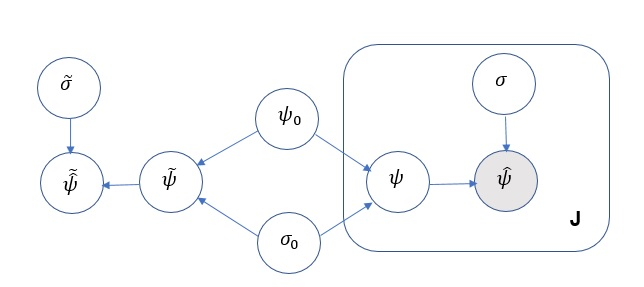

#### **(2)(e)(ii) Correspondingly modify your JAGS model to answer the following parts. Show the modified JAGS and R code and output that you used.**

```
model {
  for (j in 1:length(psi_hat)) {
    psi_hat[j] ~ dnorm(psi[j], 1/sigma[j]^2)
    psi[j] ~ dnorm(psi0, 1/sigmasq0)
  }

  psi0 ~ dnorm(0, 1/1000^2)
  sigma0 ~ dunif(0, 1000)

  sigmasq0 <- sigma0^2

  psi_hat.tilde ~ dnorm(psi.tilde, 1/sigma.tilde^2)
  psi.tilde ~ dnorm(psi0, 1/sigmasq0)

  lead.ind = psi_hat.tilde > 2*sigma.tilde
}
```

```r
m1mod = jags.model("asgn2templatemod.bug", c(as.list(d), sigma.tilde = 0.25))
```

#### **(2)(e)(iii) Estimate the posterior mean and posterior standard deviation, and form a 95% central posterior predictive interval for the estimated log-odds ratio that the new study will obtain.**

```r
update(m1mod, 10000)   #Burn-in

x1mod = coda.samples(m1mod, c("psi_hat.tilde", "lead.ind"), n.iter = 100000)
summary(x1mod)
```

```
##
## Iterations = 11001:111000
## Thinning interval = 1
## Number of chains = 1
## Sample size per chain = 100000
##
## 1. Empirical mean and standard deviation for each variable,
##    plus standard error of the mean:
##
##                Mean    SD Naive SE Time-series SE
## lead.ind      0.257 0.437  0.00138        0.00157
## psi_hat.tilde 0.214 0.481  0.00152        0.00157
##
## 2. Quantiles for each variable:
##
##                 2.5%     25%   50%   75% 97.5%
## lead.ind       0.000  0.0000 0.000 1.000  1.00
## psi_hat.tilde -0.723 -0.0882 0.207 0.509  1.19
```

**posterior mean of $\tilde{\hat{\psi}} \approx$ 0.214**

**posterior standard deviation of $\tilde{\hat{\psi}} \approx$ 0.481**

**95% central posterior interval for $\tilde{\hat{\psi}} \approx$ (-0.723, 1.191)**

#### **(2)(e)(iv) Estimate the posterior predictive probability that the new estimated log-odds ratio will be at least twice its standard error, i.e., at least two standard errors ($2\sigma$) greater than zero. (This is roughly the posterior probability that the new study will find a statistically significant result, and in the positive direction.)**

**posterior predictive probability $Pr(\tilde{\hat{\psi}} > 2\tilde{\sigma}) \approx$ 0.257**

#### **Appendix (Data)**

```
j   psi_hat   sigma
1   1.055     0.373
2  -0.097     0.116
3   0.626     0.229
4   0.017     0.117
5   1.068     0.471
6  -0.025     0.120
7  -0.117     0.220
8  -0.381     0.239
9   0.507     0.186
10  0.000     0.328
11  0.385     0.206
12  0.405     0.254
```